# Physionet Data Exploration

David Dai

Last updated: May 17, 2019

# Summary of the dataset

There are 1551920 records in the dataset, with 40330 unique subjects.

## Raw data summary

| name | type | na | mean | disp | median | mad | min | max | nlevs |
| --- | --- | --- | --- | --- | --- | --- | --- | --- | --- |
| HR | numeric | 153371 | 84.58 | 17.33 | 83.50 | 17.05 | 20.00 | 280.00 | 0 |
| O2Sat | numeric | 202705 | 97.19 | 2.94 | 98.00 | 2.97 | 20.00 | 100.00 | 0 |
| Temp | numeric | 1026800 | 36.98 | 0.77 | 37.00 | 0.74 | 20.90 | 50.00 | 0 |
| SBP | numeric | 226235 | 123.75 | 23.23 | 121.00 | 23.72 | 20.00 | 300.00 | 0 |
| MAP | numeric | 193240 | 82.40 | 16.34 | 80.00 | 14.83 | 20.00 | 300.00 | 0 |
| DBP | numeric | 486524 | 63.83 | 13.96 | 62.00 | 13.34 | 20.00 | 300.00 | 0 |
| Resp | numeric | 238253 | 18.73 | 5.10 | 18.00 | 4.45 | 1.00 | 100.00 | 0 |
| EtCO2 | logical | 1551920 | NA | NaN | NA | NA | Inf | -Inf | 0 |
| BaseExcess | numeric | 1467775 | -0.69 | 4.29 | 0.00 | 2.97 | -32.00 | 100.00 | 0 |
| HCO3 | numeric | 1486892 | 24.08 | 4.38 | 24.00 | 2.97 | 0.00 | 55.00 | 0 |
| FiO2 | numeric | 1422559 | 0.55 | 11.12 | 0.50 | 0.15 | -50.00 | 4000.00 | 0 |
| pH | numeric | 1444352 | 7.38 | 0.07 | 7.38 | 0.06 | 6.62 | 7.93 | 0 |
| PaCO2 | numeric | 1465624 | 41.02 | 9.27 | 40.00 | 7.41 | 10.00 | 100.00 | 0 |
| SaO2 | numeric | 1498360 | 92.65 | 10.89 | 97.00 | 1.63 | 23.00 | 100.00 | 0 |
| AST | numeric | 1526740 | 260.25 | 855.79 | 41.00 | 34.10 | 3.00 | 9961.00 | 0 |
| BUN | numeric | 1445368 | 23.92 | 20.00 | 17.00 | 10.38 | 1.00 | 268.00 | 0 |
| Alkalinephos | numeric | 1526982 | 102.49 | 120.13 | 74.00 | 35.58 | 7.00 | 3833.00 | 0 |
| Calcium | numeric | 1460608 | 7.56 | 2.43 | 8.30 | 0.74 | 1.00 | 27.90 | 0 |
| Chloride | numeric | 1481457 | 105.83 | 5.88 | 106.00 | 4.45 | 26.00 | 145.00 | 0 |
| Creatinine | numeric | 1457320 | 1.51 | 1.81 | 0.94 | 0.42 | 0.10 | 46.60 | 0 |
| Bilirubin_direct | numeric | 1551610 | 1.69 | 3.18 | 0.60 | 0.74 | 0.01 | 20.57 | 0 |
| Glucose | numeric | 1286454 | 136.93 | 51.31 | 127.00 | 34.10 | 10.00 | 988.00 | 0 |
| Lactate | numeric | 1510478 | 2.65 | 2.53 | 1.80 | 1.04 | 0.20 | 31.00 | 0 |
| Magnesium | numeric | 1453983 | 2.05 | 0.40 | 2.00 | 0.30 | 0.20 | 9.80 | 0 |
| Phosphate | numeric | 1489627 | 3.54 | 1.42 | 3.30 | 1.04 | 0.20 | 18.80 | 0 |
| Potassium | numeric | 1407415 | 4.14 | 0.64 | 4.10 | 0.59 | 1.00 | 27.50 | 0 |
| Bilirubin_total | numeric | 1528782 | 2.11 | 4.31 | 0.90 | 0.59 | 0.10 | 49.60 | 0 |
| TroponinI | numeric | 1538620 | 8.11 | 23.99 | 0.29 | 0.42 | 0.01 | 440.00 | 0 |
| Hct | numeric | 1414504 | 30.79 | 5.49 | 30.30 | 5.19 | 5.50 | 71.70 | 0 |
| Hgb | numeric | 1437346 | 10.43 | 1.97 | 10.30 | 1.93 | 2.20 | 32.00 | 0 |
| PTT | numeric | 1506222 | 41.23 | 26.21 | 32.40 | 8.60 | 12.50 | 250.00 | 0 |
| WBC | numeric | 1452490 | 11.45 | 7.73 | 10.30 | 4.45 | 0.10 | 440.00 | 0 |
| Fibrinogen | numeric | 1541678 | 287.39 | 153.00 | 250.00 | 114.16 | 34.00 | 1760.00 | 0 |
| Platelets | numeric | 1459728 | 196.02 | 103.64 | 181.00 | 85.99 | 1.00 | 2322.00 | 0 |
| Age | numeric | 0 | 62.01 | 16.39 | 64.00 | 16.31 | 14.00 | 100.00 | 0 |
| Gender | numeric | 0 | 0.56 | 0.50 | 1.00 | 0.00 | 0.00 | 1.00 | 0 |
| Unit1 | numeric | 611862 | 0.50 | 0.50 | 0.00 | 0.00 | 0.00 | 1.00 | 0 |
| Unit2 | numeric | 611862 | 0.50 | 0.50 | 1.00 | 0.00 | 0.00 | 1.00 | 0 |
| HospAdmTime | numeric | 8 | -56.12 | 162.27 | -6.03 | 8.91 | -5366.86 | 23.99 | 0 |
| ICULOS | numeric | 0 | 27.00 | 29.01 | 21.00 | 17.79 | 1.00 | 336.00 | 0 |
| SepsisLabel | numeric | 0 | 0.02 | 0.13 | 0.00 | 0.00 | 0.00 | 1.00 | 0 |
| subject | character | 0 | NA | 1.00 | NA | NA | 8.00 | 336.00 | 40330 |

From the raw summary, a few things are interesting:

1. Numeric ranges are quite extreme in some cases, eg. temperature ranging from 20.9 to 50
2. No non-missing values of EtCO2
3. Most values are very sparse, with lots of missing data
4. Extremely skewed distributions for various measurements, eg FiO2, AST
5. Gender, Unit1, and Unit2 are categorical variables. Additionally, Unit1 and Unit2 should be mutually exclusive.
6. HospAdmTime looks weird
7. Sepsis label is rare, occurring in 2% of records.

## Data Pre-processing

Pre-processing steps:

1. Convert gender to factor
2. Convert Unit1, Unit2 to factor
3. Convert SepsisLabel to factor
4. Remove EtCO2 from dataset

## Correlations between numeric variables

The figure below shows the Spearman correlations between all numeric variables, using all available pairwise observations. Note that due to high amount of missing data, these correlations may be biased. A deeper understanding of the missing data mechanism is required.

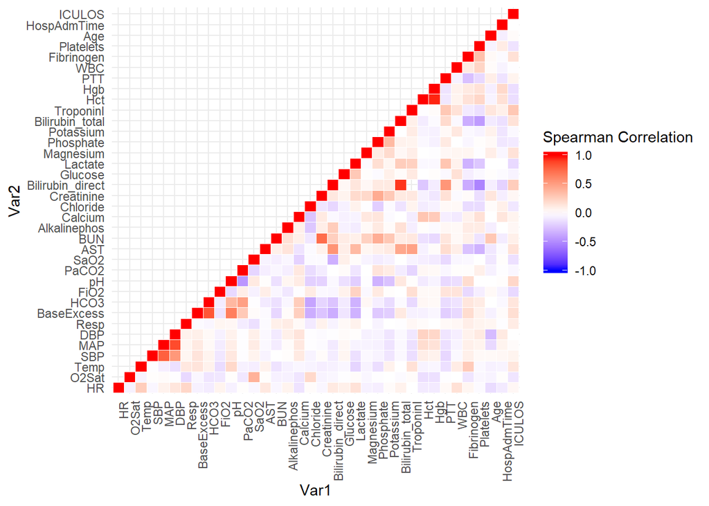